# ps_7.Rmd

Hamaad Mehal

4/6/2020

# Question 1A

Data summary

| Name | Piped data |
| --- | --- |
| Number of rows | 537 |
| Number of columns | 26 |
| _______________________ |  |
| Column type frequency: |  |
| numeric | 2 |
| ________________________ |  |
| Group variables | None |

**Variable type: numeric**

| skim_variable | n_missing | complete_rate | mean | sd | p0 | p25 | p50 | p75 | p100 | hist |
| --- | --- | --- | --- | --- | --- | --- | --- | --- | --- | --- |
| age | 0 | 1 | 58.91 | 11.78 | 30 | 50.00 | 59 | 68 | 86 | ▂▅▇▇▂ |
| nominate_percentile | 0 | 1 | 49.95 | 28.95 | 0 | 24.81 | 50 | 75 | 100 | ▇▇▇▇▇ |

# Question 1B

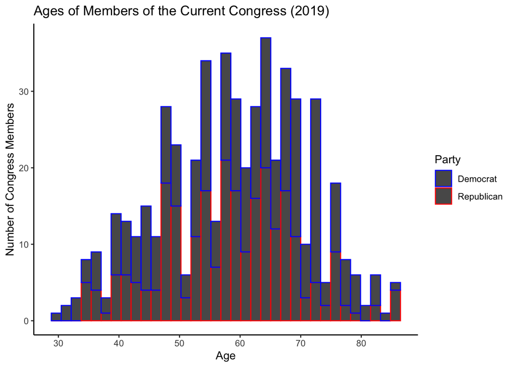

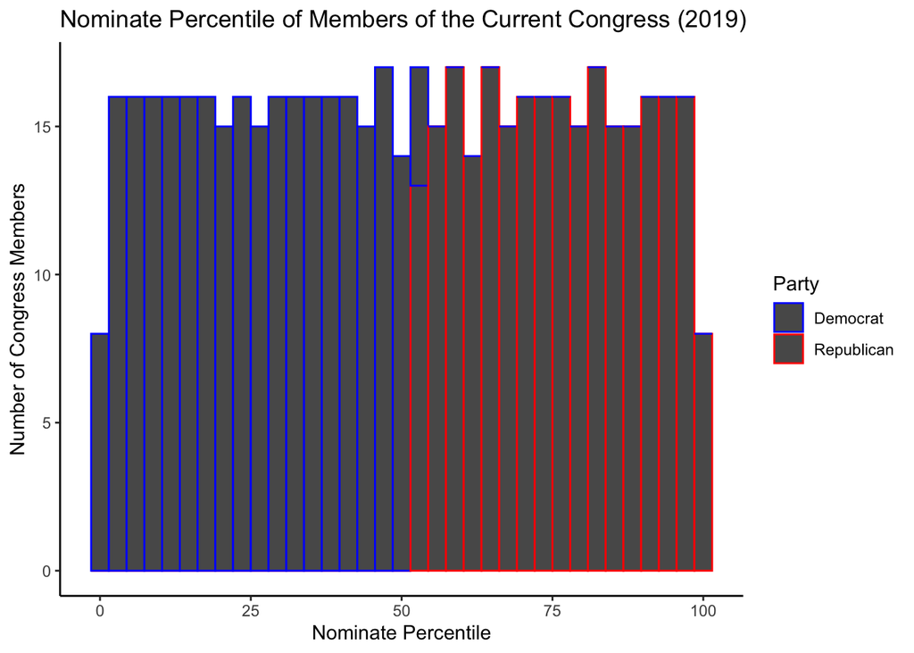

# Question 1C

-0.1593432

A negative coefficient would mean the two variables are inversely related (as one variable increases, the second decreases, so in this case, as age increases, the nominate percentile decreases) whereas a positive coefficient would mean the two variable are directly related (as one variable increases, the second increases too, so in this case, as age increases, the nominate percentile increases).

# Question 1D

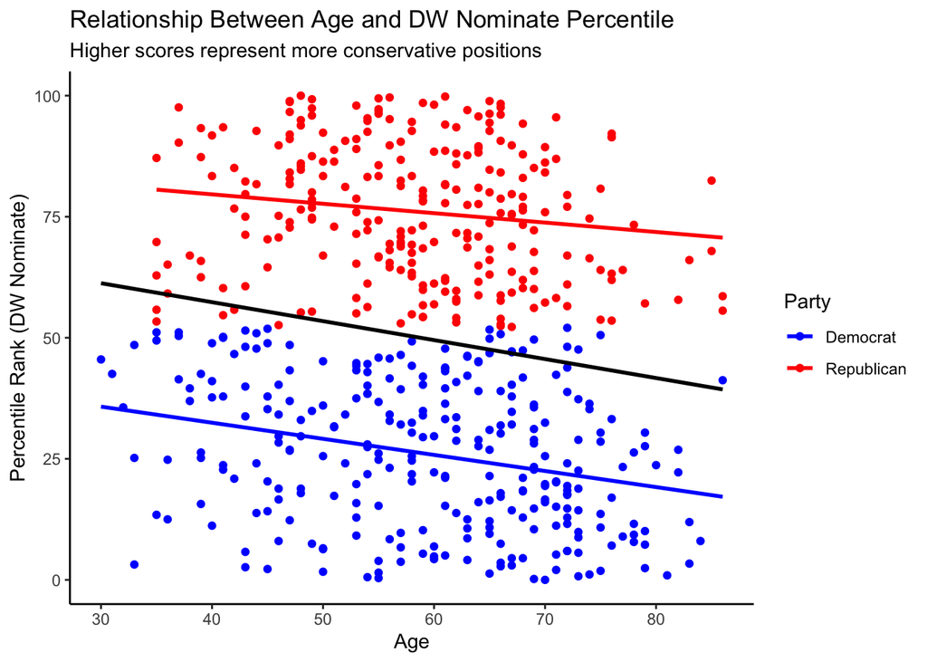

The direction of the line *does* match the sign of my correlation coefficient.

# Question 2A

Effect of Age on DW Nominate Percentile

| Higher percentile suggests more conservative Variable | Higher percentile suggests more conservative Estimate | Higher percentile suggests more conservative Lower Bound | Higher percentile suggests more conservative Upper Bound |
| --- | --- | --- | --- |
| (Intercept) | 45.7469111 | 37.4458230 | 54.0479993 |
| age | -0.3322965 | -0.4687675 | -0.1958254 |

# Question 2B

The average treatment effect is -0.3322965 as that is the effect age has on the DW Nominate Percentile. This is the case as that number is the slope of the regression line, the metric for average treatment effect. I would say being one year older lowers the democratic member of congress’s expected percentile rank for DW nominate scores by 0.3322965. We should not necessarily interpret the estimated correlation as causal because this is a mere observation. We could not experimentally manipulate any variables to try to understand if there are any underlying causation factors in the data. Older democratic senators might be less conservative due to incumbency factors that allow them to be more liberal due to their (potential) long standing in the party. We calculate a confidence interval around our average treatment effect to demonstrate the range of possible values for the average treatment effect as our average treatment effect is just an estimate with degrees of uncertainty around its accuracy.

# Question 2C

The coefficient on military would be the average treatment effect that being randomly assigned to the military has on DW nominate percentiles. However, we are not able to observe differences in potential outcomes as, per the Rubin Causal Model, we can only observe one observation at a time, a limit of this model. However, we can say this analysis is causal due to the random assignment of individuals to the treatment or control groups.

# Question 3

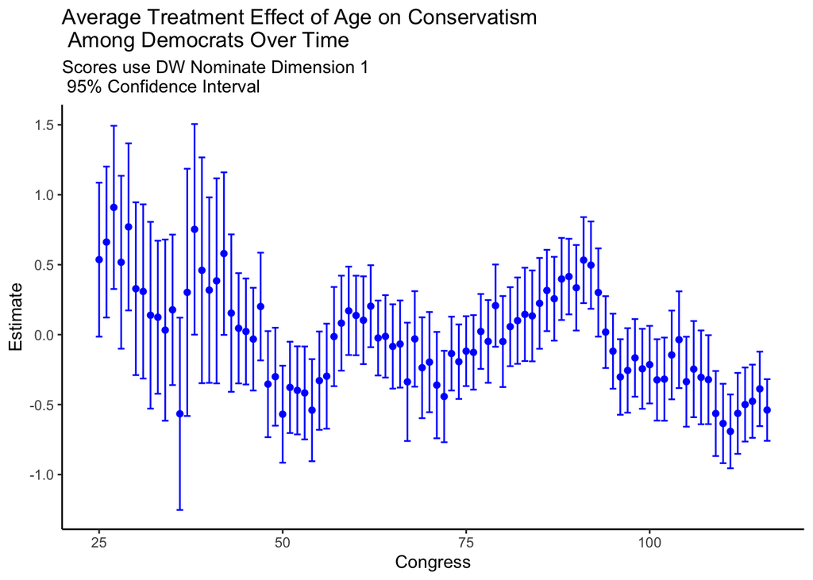

Collaborators: Ibraheem Khan, Jun Yong Kim